### German Bank Survey #4 - 2023-09-13

This **non-fishing** survey will include 9 participating vessels.

Vessels will complete the following lines: All vessels are to complete two lines each in the German Survey Box and one line in the Seal Island Box .

The Lady Melissa will conduct plankton tows and oceanographic sampling.

The survey will have a start time of 20:30:00.

Tagging will be conducted from the Canada 100, Lady Janice II, Lady Melissa, Morning Star,Tasha Marie and Sealife II.

Vessels are reminded to complete their assigned transects as listed, straight, and without deviating.

**When running your transect, if you are recording a school of fish but are near the end of your line, please continue recording in a straight line even if it extends beyond the boundaries of the survey box.**

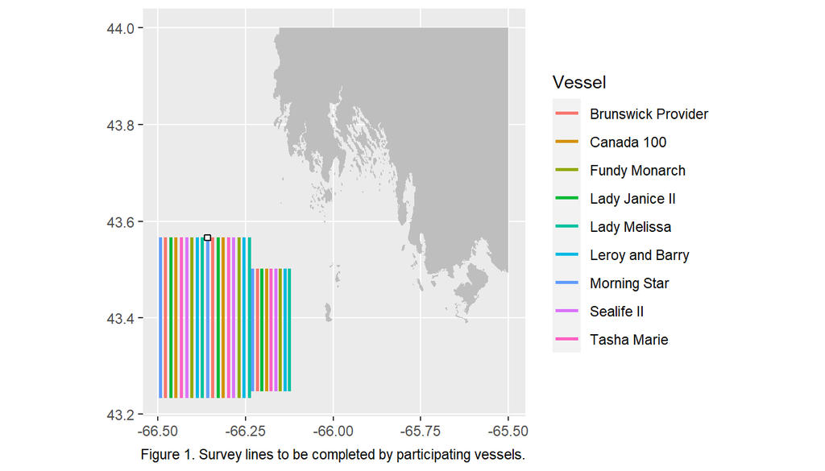

The Lady Melissa will complete both plankton towing and CTD casts (northern small box).

CTD Box

| Lat | Lon |
| --- | --- |
| 4334.320 | 6622.080 |
| 4333.600 | 6622.080 |
| 4333.600 | 6621.000 |
| 4334.320 | 6621.000 |

##### Full Lines Table

| Vessel | Start Lat | Start Lon | End Lat | End Lon |
| --- | --- | --- | --- | --- |
| Brunswick Provider | 4334.00 | 6628.706 | 4314.00 | 6628.706 |
| Brunswick Provider | 4334.00 | 6620.659 | 4314.00 | 6620.659 |
| Brunswick Provider | 4330.12 | 6613.012 | 4314.85 | 6613.012 |
| Canada 100 | 4334.00 | 6626.918 | 4314.00 | 6626.918 |
| Canada 100 | 4334.00 | 6618.871 | 4314.00 | 6618.871 |
| Canada 100 | 4330.12 | 6611.438 | 4314.85 | 6611.438 |
| Fundy Monarch | 4334.00 | 6624.235 | 4314.00 | 6624.235 |
| Fundy Monarch | 4334.00 | 6616.188 | 4314.00 | 6616.188 |
| Fundy Monarch | 4330.12 | 6609.075 | 4314.85 | 6609.075 |
| Lady Janice II | 4334.00 | 6627.812 | 4314.00 | 6627.812 |
| Lady Janice II | 4334.00 | 6619.765 | 4314.00 | 6619.765 |
| Lady Janice II | 4330.12 | 6612.225 | 4314.85 | 6612.225 |
| Lady Melissa | 4334.00 | 6622.447 | 4314.00 | 6622.447 |
| Lady Melissa | 4334.00 | 6614.400 | 4314.00 | 6614.400 |
| Lady Melissa | 4330.12 | 6607.500 | 4314.85 | 6607.500 |
| Leroy and Barry | 4334.00 | 6623.341 | 4314.00 | 6623.341 |
| Leroy and Barry | 4334.00 | 6615.294 | 4314.00 | 6615.294 |
| Leroy and Barry | 4330.12 | 6608.288 | 4314.85 | 6608.288 |
| Morning Star | 4334.00 | 6629.600 | 4314.00 | 6629.600 |
| Morning Star | 4334.00 | 6621.553 | 4314.00 | 6621.553 |
| Morning Star | 4330.12 | 6613.800 | 4314.85 | 6613.800 |
| Sealife II | 4334.00 | 6625.129 | 4314.00 | 6625.129 |
| Sealife II | 4334.00 | 6617.082 | 4314.00 | 6617.082 |
| Sealife II | 4330.12 | 6609.863 | 4314.85 | 6609.863 |
| Tasha Marie | 4334.00 | 6626.024 | 4314.00 | 6626.024 |
| Tasha Marie | 4334.00 | 6617.976 | 4314.00 | 6617.976 |
| Tasha Marie | 4330.12 | 6610.650 | 4314.85 | 6610.650 |

### Instructions

1. Plan to arrive at the starting point 30 minutes before the start time of 20:30:00.
2. Start the EK80 software and load the ‘Herring Survey 2023’ settings. When you are ready to begin, Record Raw should be turned ‘ON’ and the ‘REC’ dot in the upper left should turn from black to red. Finally, check that the lat and long in the top center of the screen is changing.
3. Commence surveying first line at 20:30:00 and maintain a speed at 8 knots.
4. Run your lines straight and double check that the recorder is turned on and red.
5. Maintain deck sheets as a backup to recorders every 15 minutes.
6. Note the time when finished your last line.
7. Fishing to start on 2023-09-14, and allocation is 200mt/vessel for German Bank and 100mt/vessel for Seal Island.